Skip to poster content

CHI 2026 poster

# Exploring the Role of User Comments Throughout the Stages of Video-Based Task-Learning

Nayoung Kim<sup>1,a</sup>, Yotam Sechayk<sup>1,b</sup>, Zhongyi Zhou<sup>b,c</sup>, Takeo Igarashi<sup>b</sup>

<sup>1</sup>These authors contributed equally. <sup>a</sup>KAIST, <sup>b</sup>The University of Tokyo, <sup>c</sup>Google

- [Paper (ACM Digital Library)](https://doi.org/10.1145/3772363.3799031)
- [Paper (arXiv)](https://arxiv.org/abs/2603.12509)
- yotam@sechayk.com
- sechayk.com

## 1. Introduction

**Video-based task learning is widespread, but not personalized.**

- **Video** shows processes, but **a fixed viewpoint limits tacit knowledge**.
- Learners **turn to comments** to fill this gap.
- **Comments support:**
- Questions
- Goals
- Experience
- Explanations

However… **the role of comments** in the learning process is **under-explored**.

We look at three stages of learning from a video:

1. **Before:** search
2. **During:** watch
3. **After:** reflect

## 2. Exploratory study

### Methodology

- Semi-structured interviews (about 30 minutes each, 14 participants)
- Co-watching sessions (about 30 minutes each, 8 participants)
- Analyzed using thematic analysis

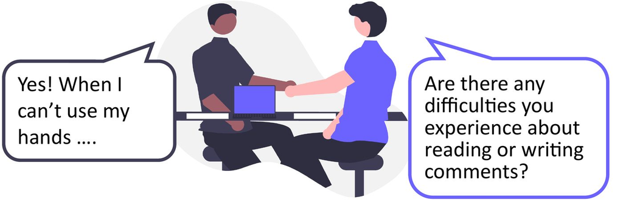

## 3. Findings: the role of comments across learning stages

### Before: trust and video selection

- Comments act as **trust signals** for video selection.
- Comments reduce uncertainty before learning starts.

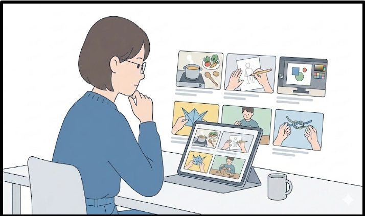

Video browsing

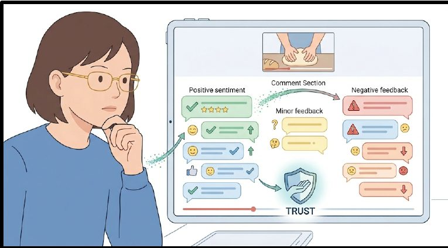

Reading comments for trust

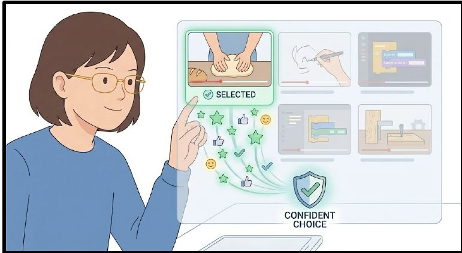

Decision making

### During: sensemaking and personalization

- Enable **collaborative understanding and adaptation**.
- Transform passive watching into **active learning**.

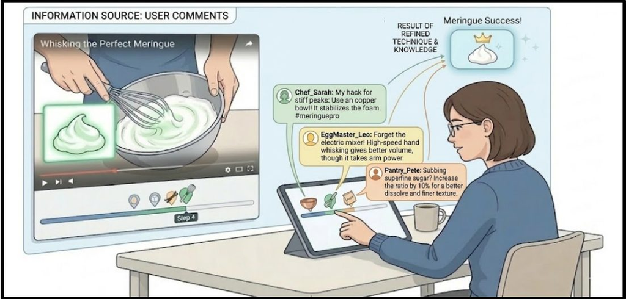

Step-specific explanation for understanding

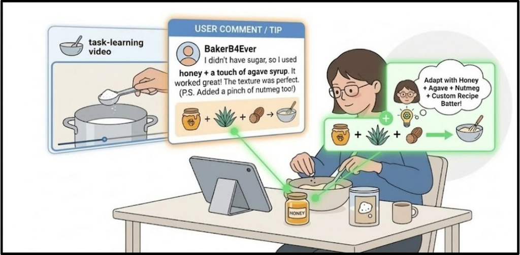

Adapt actions to users’ own context

### After: reflection and extension

- Comments support **reflection and deeper learning**.
- Comments extend learning **beyond the video**.

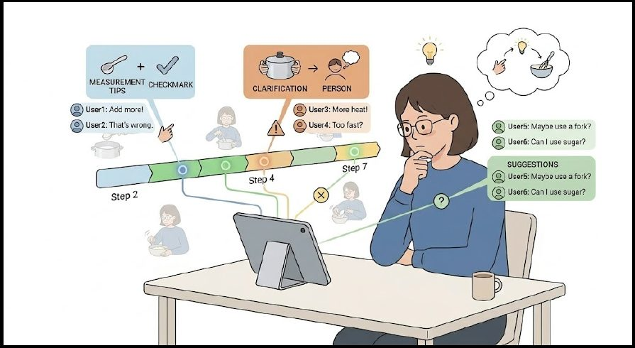

Look back and deepen understanding

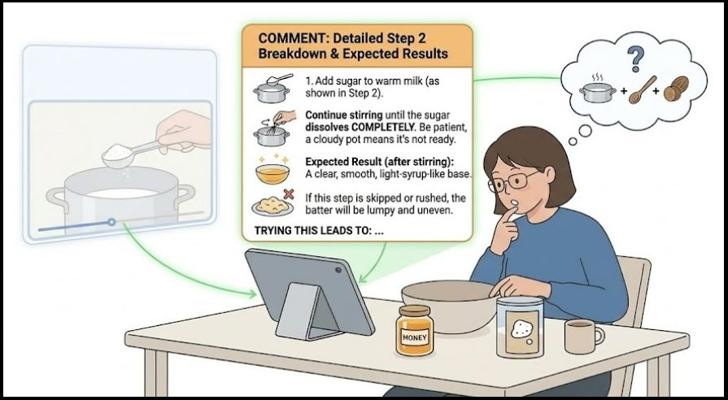

Learn more beyond the video

### Surfaced challenges

- Difficult comment discovery
- Disrupted task flow
- Limited access

## 4. Design opportunities

Transform **comments** from passive content into an integrated, **stage-aware learning support system**.

### Support informed video selection

Surface collective signals from comments.

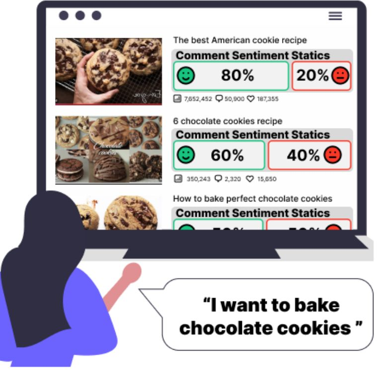

### Enable in-situ sensemaking

Embed step-based insights directly into video playback.

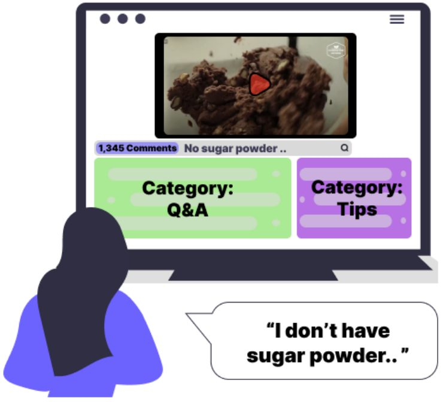

### Reflection and knowledge extension

Structure feedback by step for effortless navigation and analysis.

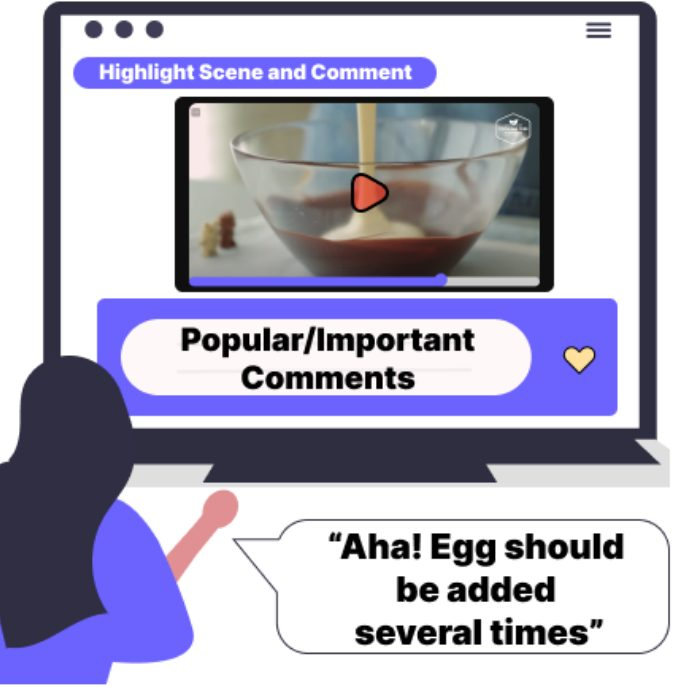

### Improve access and navigation

Minimize manual navigation and noise to enable seamless, hands-free mobile access.

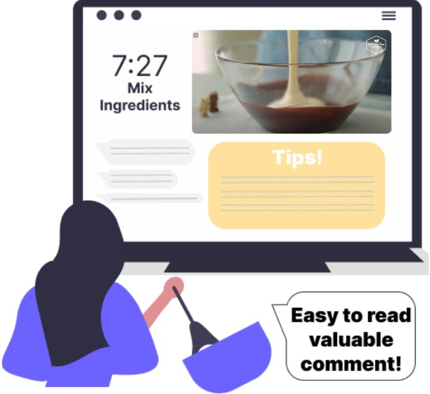

## 5. Limitation and future work

Research should explore **broader demographics and diverse platforms** to better decode the underlying motivations for social commenting.

[Read the paper on arXiv](https://arxiv.org/abs/2603.12509)